# Estudio y preproceso de la base de datos del INE

Nadal

2025-05-26

# Análisis de la relación Renta media por barrio-Precio de alquiler de Airbnb

# Análisis exploratorio

```r
library(dplyr);
library(knitr);
library(lubridate);
library(stats);
library(FactoMineR);
library(factoextra);
library(amap);
library(mdatools);
library(grid)
library(gridExtra)
print('Paquetes importados')
```

```
## [1] "Paquetes importados"
```

####Lectura y limpieza de datos

```r
#install.packages('readxl')
library(readxl)
INE = read_excel('INE.xlsx')
INE_limpio = INE[,1:41]
numNA = apply(INE_limpio, 2, function(x) sum(is.na(x)))
numNA
```

```
##               Zona       2022_persona       2021_persona       2020_persona
##                  0                 25                 30                 41
##       2019_persona       2018_persona       2017_persona       2016_persona
##                 35                 35                 31                 31
##       2015_persona         2022_hogar         2021_hogar         2020_hogar
##                 31                 25                 30                 41
##         2019_hogar         2018_hogar         2017_hogar         2016_hogar
##                 35                 35                 31                 31
##         2015_hogar       2022_consumo       2021_consumo       2020_consumo
##                 31                 25                 30                 41
##       2019_consumo       2018_consumo       2017_consumo       2016_consumo
##                 35                 35                 34                 34
##       2015_consumo 2022_bruta_persona 2021_bruta_persona 2020_bruta_persona
##                 34                 25                 30                 41
## 2019_bruta_persona 2018_bruta_persona 2017_bruta_persona 2016_bruta_persona
##                 35                 35                 34                 34
## 2015_bruta_persona   2022_bruta_hogar   2021_bruta_hogar   2020_bruta_hogar
##                 34                 25                 30                 41
##   2019_bruta_hogar   2018_bruta_hogar   2017_bruta_hogar   2016_bruta_hogar
##                 35                 35                 34                 34
##   2015_bruta_hogar
##                 34
```

```r
tablaNA = data.frame("Variable" = colnames(INE_limpio), numNA)
tablaNA
```

```
##                              Variable numNA
## Zona                             Zona     0
## 2022_persona             2022_persona    25
## 2021_persona             2021_persona    30
## 2020_persona             2020_persona    41
## 2019_persona             2019_persona    35
## 2018_persona             2018_persona    35
## 2017_persona             2017_persona    31
## 2016_persona             2016_persona    31
## 2015_persona             2015_persona    31
## 2022_hogar                 2022_hogar    25
## 2021_hogar                 2021_hogar    30
## 2020_hogar                 2020_hogar    41
## 2019_hogar                 2019_hogar    35
## 2018_hogar                 2018_hogar    35
## 2017_hogar                 2017_hogar    31
## 2016_hogar                 2016_hogar    31
## 2015_hogar                 2015_hogar    31
## 2022_consumo             2022_consumo    25
## 2021_consumo             2021_consumo    30
## 2020_consumo             2020_consumo    41
## 2019_consumo             2019_consumo    35
## 2018_consumo             2018_consumo    35
## 2017_consumo             2017_consumo    34
## 2016_consumo             2016_consumo    34
## 2015_consumo             2015_consumo    34
## 2022_bruta_persona 2022_bruta_persona    25
## 2021_bruta_persona 2021_bruta_persona    30
## 2020_bruta_persona 2020_bruta_persona    41
## 2019_bruta_persona 2019_bruta_persona    35
## 2018_bruta_persona 2018_bruta_persona    35
## 2017_bruta_persona 2017_bruta_persona    34
## 2016_bruta_persona 2016_bruta_persona    34
## 2015_bruta_persona 2015_bruta_persona    34
## 2022_bruta_hogar     2022_bruta_hogar    25
## 2021_bruta_hogar     2021_bruta_hogar    30
## 2020_bruta_hogar     2020_bruta_hogar    41
## 2019_bruta_hogar     2019_bruta_hogar    35
## 2018_bruta_hogar     2018_bruta_hogar    35
## 2017_bruta_hogar     2017_bruta_hogar    34
## 2016_bruta_hogar     2016_bruta_hogar    34
## 2015_bruta_hogar     2015_bruta_hogar    34
```

```r
INE_limpio <- na.omit(INE_limpio)
```

###tipos de variables

```r
descdat = data.frame("variable" = colnames(INE_limpio),
                     "tipo" = c('categorical', rep('numerical', 40)), stringsAsFactors = FALSE)
rownames(descdat) = descdat$variable
descdat
```

```
##                              variable        tipo
## Zona                             Zona categorical
## 2022_persona             2022_persona   numerical
## 2021_persona             2021_persona   numerical
## 2020_persona             2020_persona   numerical
## 2019_persona             2019_persona   numerical
## 2018_persona             2018_persona   numerical
## 2017_persona             2017_persona   numerical
## 2016_persona             2016_persona   numerical
## 2015_persona             2015_persona   numerical
## 2022_hogar                 2022_hogar   numerical
## 2021_hogar                 2021_hogar   numerical
## 2020_hogar                 2020_hogar   numerical
## 2019_hogar                 2019_hogar   numerical
## 2018_hogar                 2018_hogar   numerical
## 2017_hogar                 2017_hogar   numerical
## 2016_hogar                 2016_hogar   numerical
## 2015_hogar                 2015_hogar   numerical
## 2022_consumo             2022_consumo   numerical
## 2021_consumo             2021_consumo   numerical
## 2020_consumo             2020_consumo   numerical
## 2019_consumo             2019_consumo   numerical
## 2018_consumo             2018_consumo   numerical
## 2017_consumo             2017_consumo   numerical
## 2016_consumo             2016_consumo   numerical
## 2015_consumo             2015_consumo   numerical
## 2022_bruta_persona 2022_bruta_persona   numerical
## 2021_bruta_persona 2021_bruta_persona   numerical
## 2020_bruta_persona 2020_bruta_persona   numerical
## 2019_bruta_persona 2019_bruta_persona   numerical
## 2018_bruta_persona 2018_bruta_persona   numerical
## 2017_bruta_persona 2017_bruta_persona   numerical
## 2016_bruta_persona 2016_bruta_persona   numerical
## 2015_bruta_persona 2015_bruta_persona   numerical
## 2022_bruta_hogar     2022_bruta_hogar   numerical
## 2021_bruta_hogar     2021_bruta_hogar   numerical
## 2020_bruta_hogar     2020_bruta_hogar   numerical
## 2019_bruta_hogar     2019_bruta_hogar   numerical
## 2018_bruta_hogar     2018_bruta_hogar   numerical
## 2017_bruta_hogar     2017_bruta_hogar   numerical
## 2016_bruta_hogar     2016_bruta_hogar   numerical
## 2015_bruta_hogar     2015_bruta_hogar   numerical
```

###Arreglo de variables

```r
str(INE_limpio[, descdat$variable[descdat$tipo == "numerical"]])
```

```
## tibble [2,412 × 40] (S3: tbl_df/tbl/data.frame)
##  $ 2022_persona      : num [1:2412] 11574 11574 11574 12267 12267 ...
##  $ 2021_persona      : chr [1:2412] "11200" "11200" "11200" "11573" ...
##  $ 2020_persona      : num [1:2412] 10467 10467 10467 11010 11010 ...
##  $ 2019_persona      : chr [1:2412] "10176" "10176" "10176" "10613" ...
##  $ 2018_persona      : chr [1:2412] "9785" "9785" "9785" "10588" ...
##  $ 2017_persona      : chr [1:2412] "8739" "8739" "8739" "10233" ...
##  $ 2016_persona      : chr [1:2412] "8470" "8470" "8470" "9519" ...
##  $ 2015_persona      : chr [1:2412] "8280" "8280" "8280" "9345" ...
##  $ 2022_hogar        : num [1:2412] 25942 25942 25942 28814 28814 ...
##  $ 2021_hogar        : chr [1:2412] "25662" "25662" "25662" "27242" ...
##  $ 2020_hogar        : num [1:2412] 24164 24164 24164 26612 26612 ...
##  $ 2019_hogar        : chr [1:2412] "23610" "23610" "23610" "26147" ...
##  $ 2018_hogar        : chr [1:2412] "22739" "22739" "22739" "25111" ...
##  $ 2017_hogar        : chr [1:2412] "20715" "20715" "20715" "24006" ...
```

[output cut: 28 more lines]

```r
INE_limpio[, descdat$variable[descdat$tipo == "numerical"]] <-
  lapply(INE_limpio[, descdat$variable[descdat$tipo == "numerical"]], function(x) as.numeric(as.character(x)))
```

####summary

```r
summary(INE_limpio[,descdat$variable[descdat$tipo == "numerical"]])
```

```
##   2022_persona    2021_persona    2020_persona    2019_persona
##  Min.   : 5448   Min.   : 5056   Min.   : 4648   Min.   : 4353
##  1st Qu.:11653   1st Qu.:11030   1st Qu.:10552   1st Qu.:10370
##  Median :12617   Median :11915   Median :11496   Median :11265
##  Mean   :13315   Mean   :12600   Mean   :12116   Mean   :11935
##  3rd Qu.:14169   3rd Qu.:13486   3rd Qu.:12870   3rd Qu.:12679
##  Max.   :34765   Max.   :32039   Max.   :31670   Max.   :32183
##                  NA's   :3                       NA's   :3
##   2018_persona    2017_persona    2016_persona    2015_persona
##  Min.   : 3741   Min.   : 3431   Min.   : 3268   Min.   : 3281
##  1st Qu.: 9850   1st Qu.: 9312   1st Qu.: 8891   1st Qu.: 8648
##  Median :10674   Median :10171   Median : 9734   Median : 9530
##  Mean   :11432   Mean   :10821   Mean   :10415   Mean   :10159
##  3rd Qu.:12055   3rd Qu.:11523   3rd Qu.:11125   3rd Qu.:10854
##  Max.   :32242   Max.   :30210   Max.   :29364   Max.   :28350
##  NA's   :3       NA's   :3       NA's   :3       NA's   :3
##    2022_hogar      2021_hogar      2020_hogar      2019_hogar
##  Min.   :16475   Min.   :15556   Min.   :14573   Min.   :13709
##  1st Qu.:28545   1st Qu.:27069   1st Qu.:26070   1st Qu.:25816
##  Median :31226   Median :29477   Median :28479   Median :28275
##  Mean   :33176   Mean   :31353   Mean   :30278   Mean   :30077
##  3rd Qu.:35105   3rd Qu.:33176   3rd Qu.:31925   3rd Qu.:31783
##  Max.   :98221   Max.   :88031   Max.   :89731   Max.   :91479
##                  NA's   :3                       NA's   :3
##    2018_hogar      2017_hogar      2016_hogar      2015_hogar
##  Min.   :12537   Min.   :12087   Min.   :11550   Min.   :11388
##  1st Qu.:24513   1st Qu.:23270   1st Qu.:22512   1st Qu.:21951
##  Median :26949   Median :25620   Median :24735   Median :24022
##  Mean   :28839   Mean   :27369   Mean   :26543   Mean   :25820
##  3rd Qu.:30285   3rd Qu.:29004   3rd Qu.:28046   3rd Qu.:27252
##  Max.   :91933   Max.   :86006   Max.   :83082   Max.   :80135
##  NA's   :3       NA's   :3       NA's   :3       NA's   :3
##   2022_consumo    2021_consumo    2020_consumo    2019_consumo
##  Min.   : 8671   Min.   : 8126   Min.   : 7536   Min.   : 6994
##  1st Qu.:17252   1st Qu.:16390   1st Qu.:15652   1st Qu.:15404
##  Median :18673   Median :17631   Median :16981   Median :16772
##  Mean   :19821   Mean   :18771   Mean   :18044   Mean   :17846
##  3rd Qu.:21078   3rd Qu.:19960   3rd Qu.:19071   3rd Qu.:18866
##  Max.   :55987   Max.   :51860   Max.   :51053   Max.   :51671
##                  NA's   :3                       NA's   :3
```

[output cut: 25 more lines]

```
##  Min.   : 5838    Min.   : 5379    Min.   : 4940    Min.   : 4653
##  1st Qu.:13709    1st Qu.:12928    1st Qu.:12279    1st Qu.:12032
##  Median :15117    Median :14289    Median :13602    Median :13367
##  Mean   :17694    Mean   :16662    Mean   :15883    Mean   :15670
##  3rd Qu.:18190    3rd Qu.:17207    3rd Qu.:16426    3rd Qu.:16309
##  Max.   :64978    Max.   :60164    Max.   :60953    Max.   :60476
##                   NA's   :3                         NA's   :3
##  2018_bruta_hogar 2017_bruta_hogar 2016_bruta_hogar 2015_bruta_hogar
##  Min.   : 3975    Min.   : 3630    Min.   : 3452    Min.   : 3466
##  1st Qu.:11382    1st Qu.:10763    1st Qu.:10228    1st Qu.: 9944
##  Median :12645    Median :12039    Median :11537    Median :11224
##  Mean   :14978    Mean   :14142    Mean   :13605    Mean   :13201
##  3rd Qu.:15476    3rd Qu.:14675    3rd Qu.:14154    3rd Qu.:13806
##  Max.   :53643    Max.   :53760    Max.   :61649    Max.   :48222
##  NA's   :3        NA's   :3        NA's   :3        NA's   :3
```

```r
INE_limpio = na.omit(INE_limpio)
```

### Variabilidad de las variables numéricas (desviación típica)

```r
mySD = apply(INE_limpio[,descdat$variable[descdat$tipo == "numerical"]], 2, sd, na.rm=TRUE)   #Calculamos la desviación típica (SD)
mySD
```

```
##       2022_persona       2021_persona       2020_persona       2019_persona
##           3039.824           2804.949           2825.666           2834.567
##       2018_persona       2017_persona       2016_persona       2015_persona
##           2958.074           2670.983           2696.886           2640.457
##         2022_hogar         2021_hogar         2020_hogar         2019_hogar
##           8523.759           7926.049           7938.963           7916.909
##         2018_hogar         2017_hogar         2016_hogar         2015_hogar
##           8219.209           7498.360           7481.271           7293.856
##       2022_consumo       2021_consumo       2020_consumo       2019_consumo
##           4908.753           4506.137           4501.790           4536.123
##       2018_consumo       2017_consumo       2016_consumo       2015_consumo
##           4657.834           4247.735           4293.013           4158.735
## 2022_bruta_persona 2021_bruta_persona 2020_bruta_persona 2019_bruta_persona
##           3937.933           3715.518           3613.087           3644.381
## 2018_bruta_persona 2017_bruta_persona 2016_bruta_persona 2015_bruta_persona
##           3550.777           3442.404           3415.396           3358.794
##   2022_bruta_hogar   2021_bruta_hogar   2020_bruta_hogar   2019_bruta_hogar
##           7608.965           7056.536           6829.344           6847.626
##   2018_bruta_hogar   2017_bruta_hogar   2016_bruta_hogar   2015_bruta_hogar
##           6707.984           6259.232           6215.397           5907.340
```

#### Mejor calcular el coeficiente de variación porque no depende de las unidades o magnitud de las variables

```r
myMU = colMeans(INE_limpio[,descdat$variable[descdat$tipo == "numerical"]], na.rm=TRUE)
myMU#La media
```

```
##       2022_persona       2021_persona       2020_persona       2019_persona
##           13313.96           12600.02           12117.18           11935.16
##       2018_persona       2017_persona       2016_persona       2015_persona
##           11432.46           10820.83           10415.29           10159.43
##         2022_hogar         2021_hogar         2020_hogar         2019_hogar
##           33176.22           31353.40           30284.17           30076.58
##         2018_hogar         2017_hogar         2016_hogar         2015_hogar
##           28839.43           27369.03           26543.45           25819.59
##       2022_consumo       2021_consumo       2020_consumo       2019_consumo
##           19820.57           18771.35           18046.41           17845.86
##       2018_consumo       2017_consumo       2016_consumo       2015_consumo
##           17105.08           16202.53           15625.43           15207.90
## 2022_bruta_persona 2021_bruta_persona 2020_bruta_persona 2019_bruta_persona
##           17741.58           16784.22           16059.05           15900.92
## 2018_bruta_persona 2017_bruta_persona 2016_bruta_persona 2015_bruta_persona
##           15138.66           14355.79           13725.73           13366.50
##   2022_bruta_hogar   2021_bruta_hogar   2020_bruta_hogar   2019_bruta_hogar
##           17694.97           16661.58           15886.75           15670.44
##   2018_bruta_hogar   2017_bruta_hogar   2016_bruta_hogar   2015_bruta_hogar
##           14977.59           14142.27           13604.81           13200.86
```

```r
myCV = mySD/myMU  #Obtenemos el coeficiente de variación (que al dividir por la media eliminamos las magnitudes)
sort(myCV)  #Mostramos ordenando por coeficiente de variación
```

```
## 2021_bruta_persona 2022_bruta_persona       2021_persona 2020_bruta_persona
##          0.2213697          0.2219607          0.2226146          0.2249876
##       2022_persona 2019_bruta_persona       2020_persona 2018_bruta_persona
##          0.2283186          0.2291932          0.2331950          0.2345503
##       2019_persona 2017_bruta_persona       2021_consumo       2017_persona
##          0.2374973          0.2397920          0.2400540          0.2468373
##       2022_consumo 2016_bruta_persona       2020_consumo 2015_bruta_persona
##          0.2476595          0.2488317          0.2494563          0.2512845
##         2021_hogar       2019_consumo         2022_hogar       2018_persona
##          0.2527971          0.2541835          0.2569238          0.2587434
##       2016_persona       2015_persona         2020_hogar       2017_consumo
##          0.2589353          0.2599020          0.2621490          0.2621650
##         2019_hogar       2018_consumo       2015_consumo         2017_hogar
##          0.2632250          0.2723070          0.2734590          0.2739724
##       2016_consumo         2016_hogar         2015_hogar         2018_hogar
##          0.2747453          0.2818500          0.2824931          0.2849990
##   2021_bruta_hogar   2020_bruta_hogar   2022_bruta_hogar   2019_bruta_hogar
##          0.4235214          0.4298767          0.4300072          0.4369771
##   2017_bruta_hogar   2015_bruta_hogar   2018_bruta_hogar   2016_bruta_hogar
##          0.4425905          0.4474966          0.4478680          0.4568529
```

### Valores atípicos

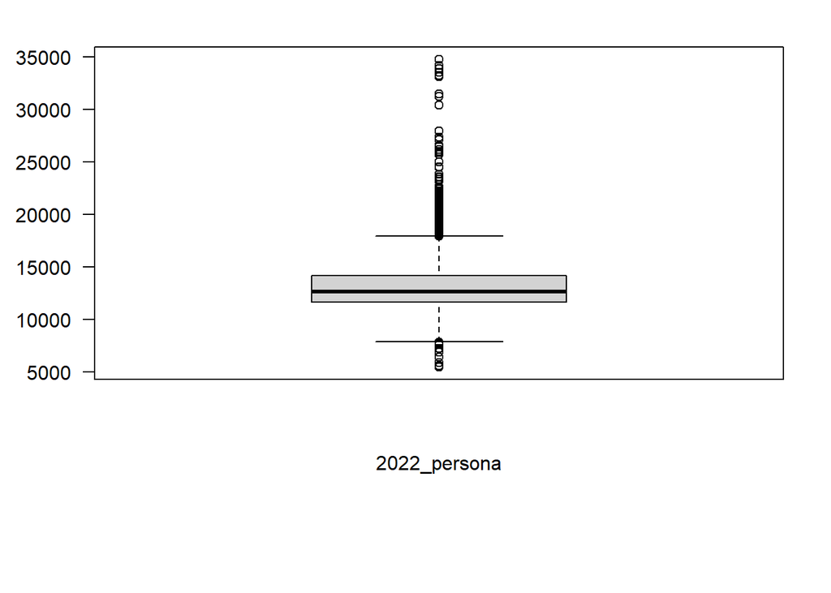

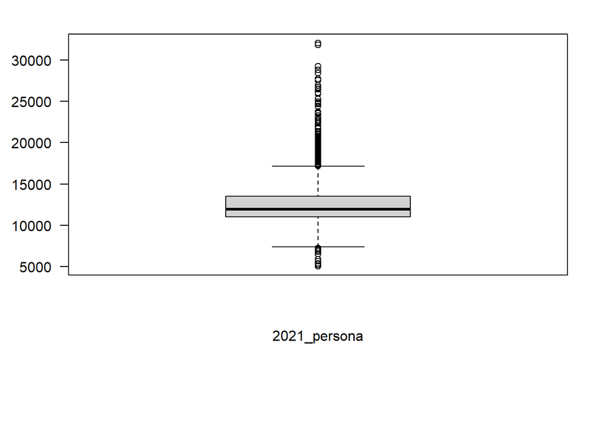

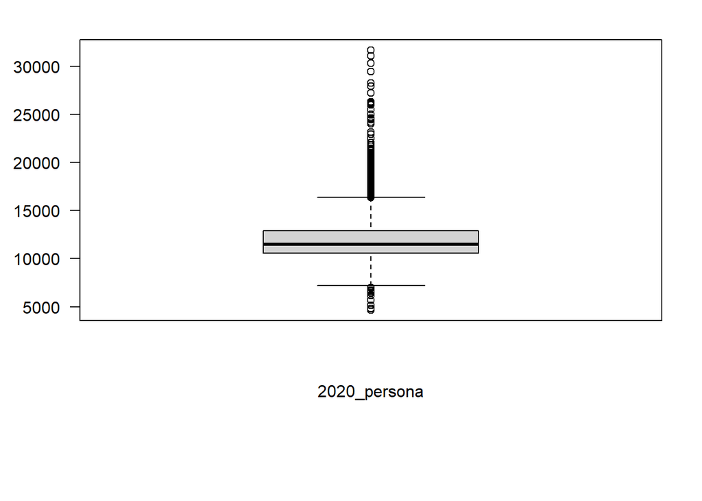

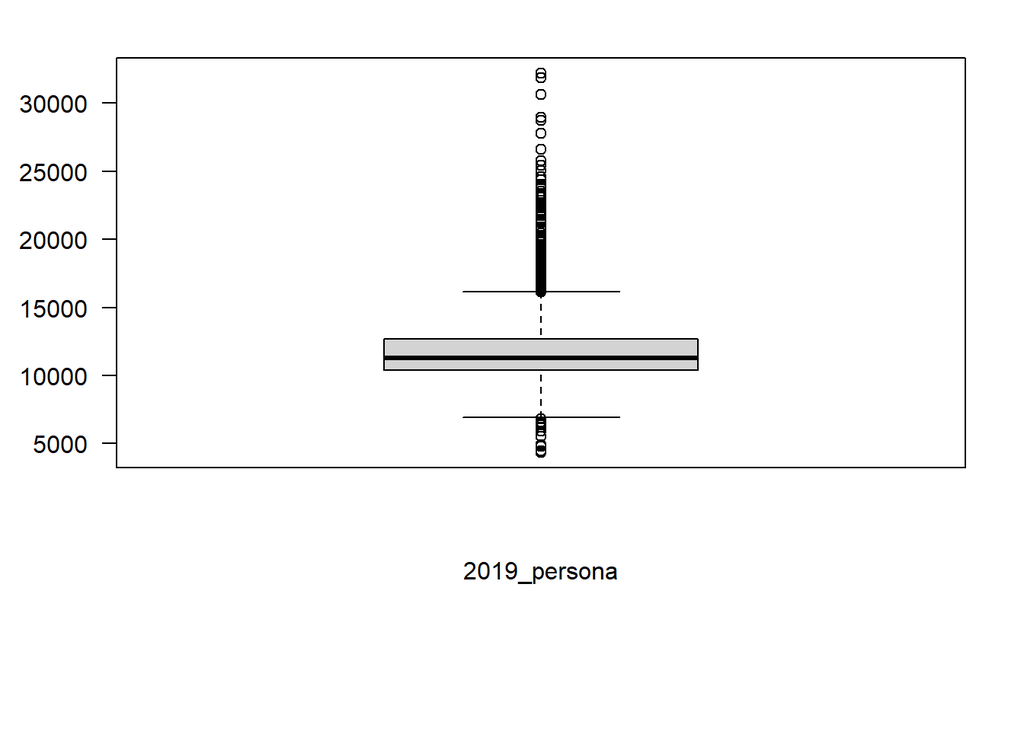

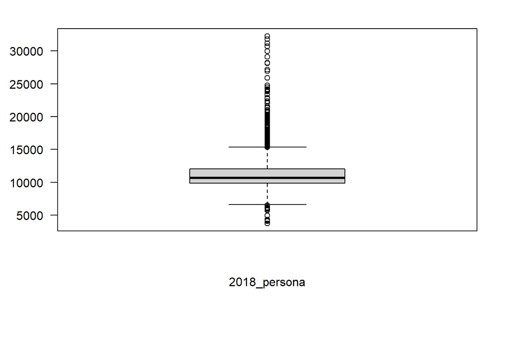

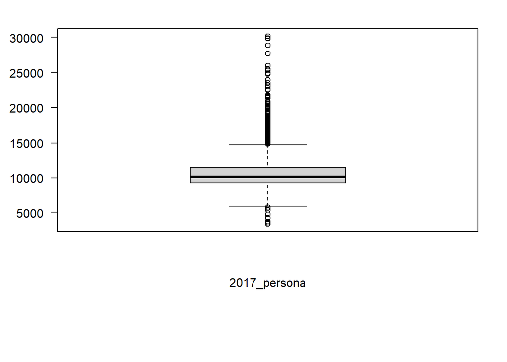

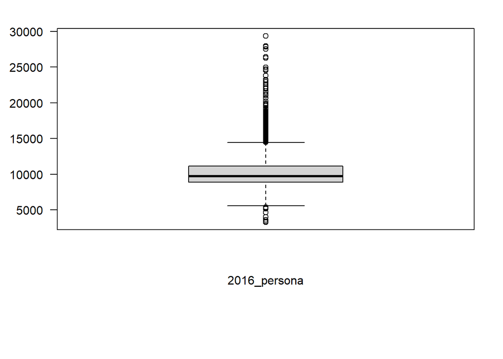

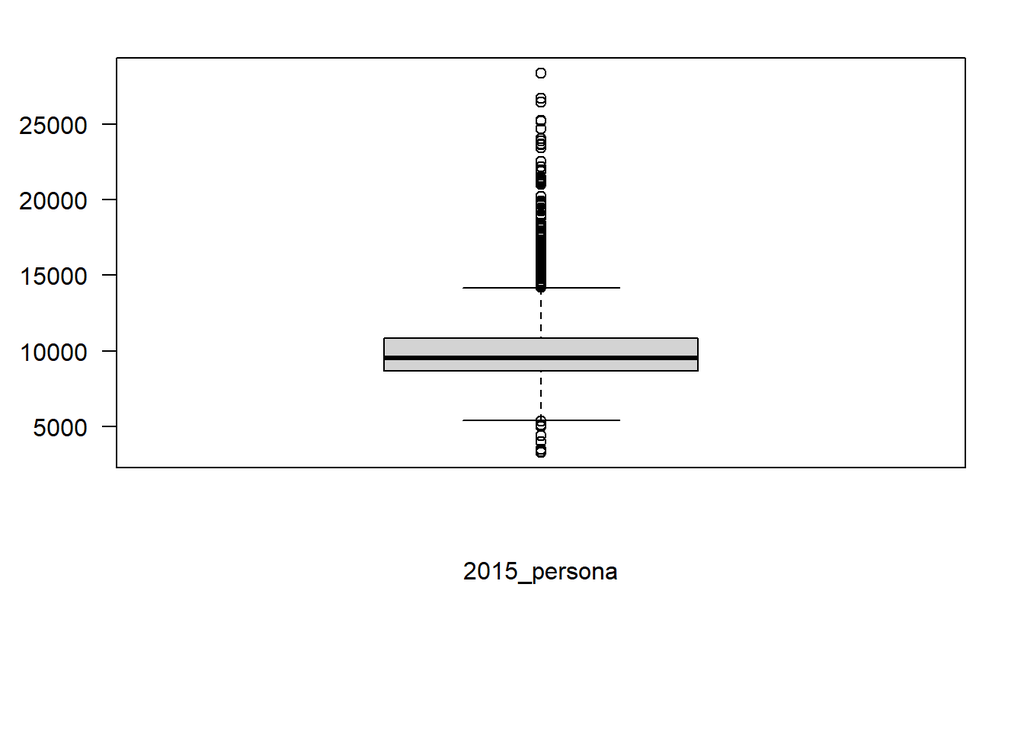

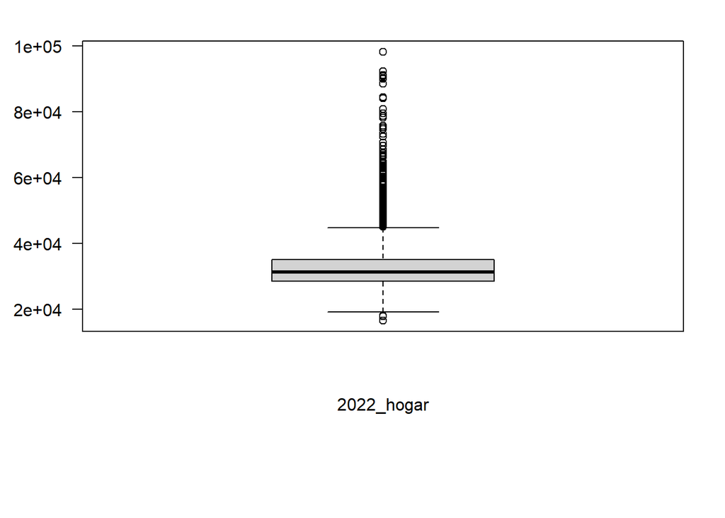

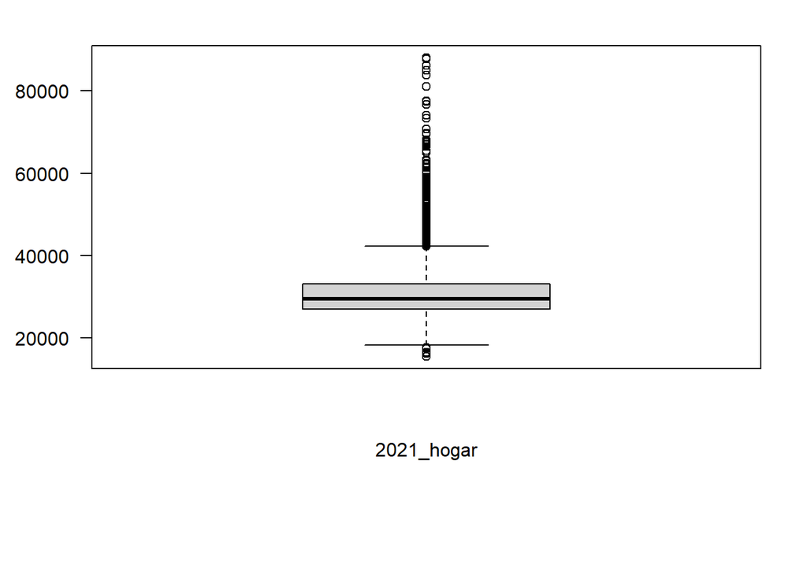

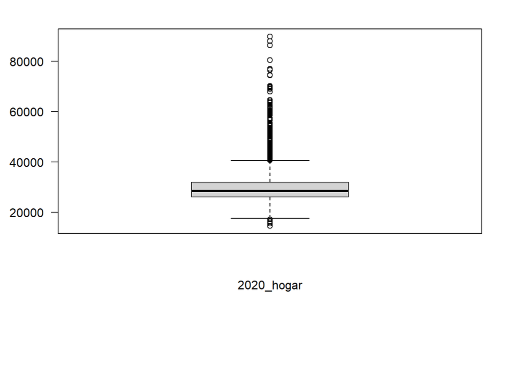

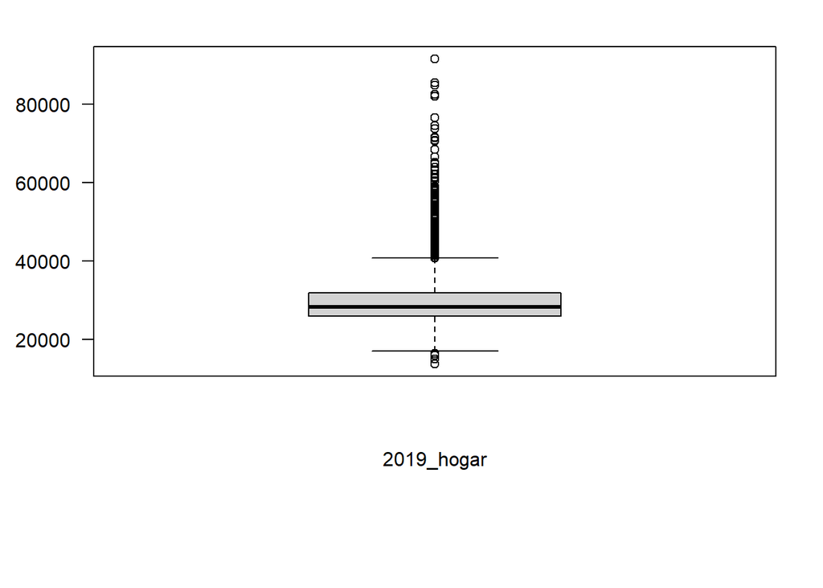

[28 more figures not shown]

```r
for (fila in descdat$variable[descdat$tipo=="numerical"]) {
  par(mar = c(9,4,2,2))
  boxplot(INE_limpio[,fila],xlab=fila,las = 2)   # mfcol
}
```

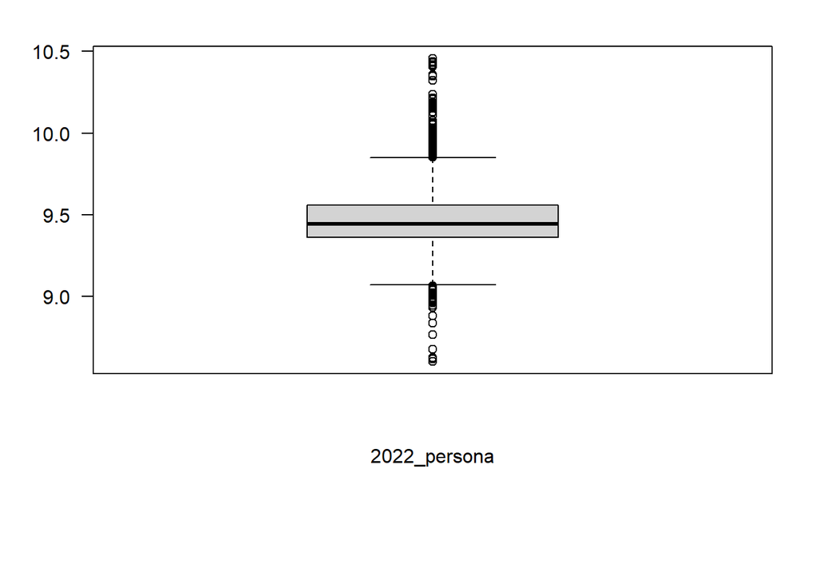

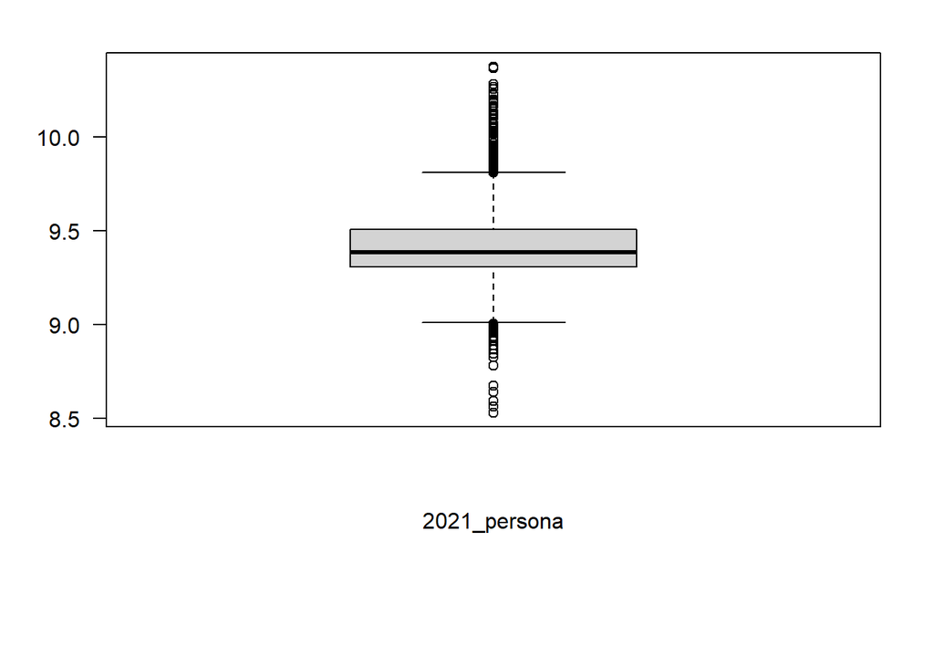

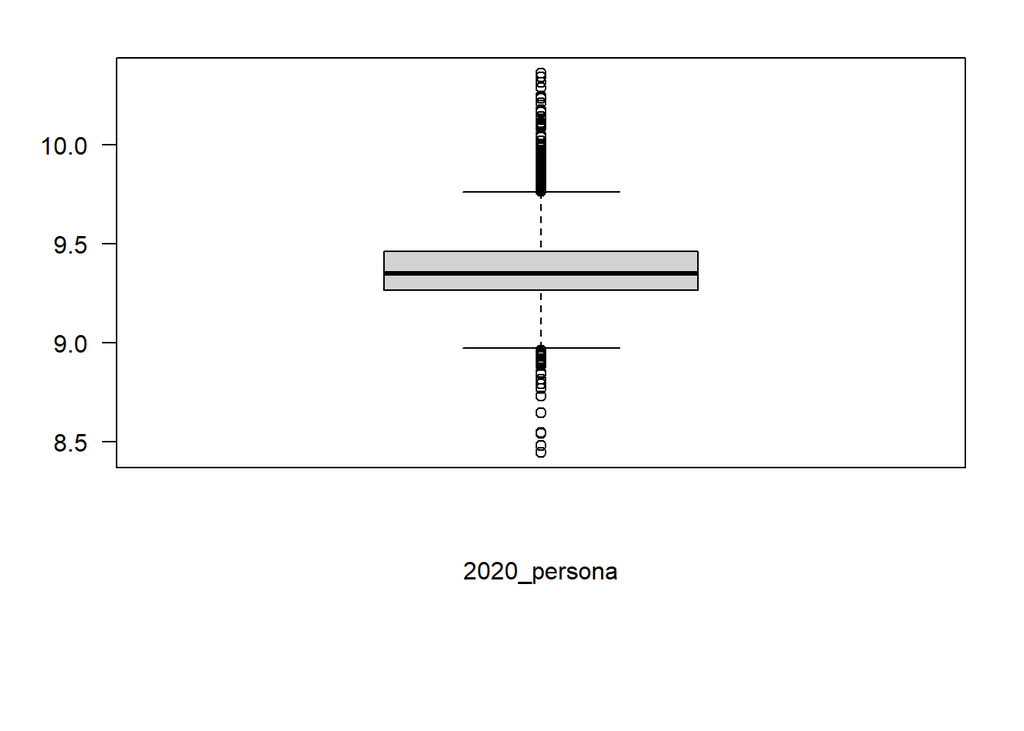

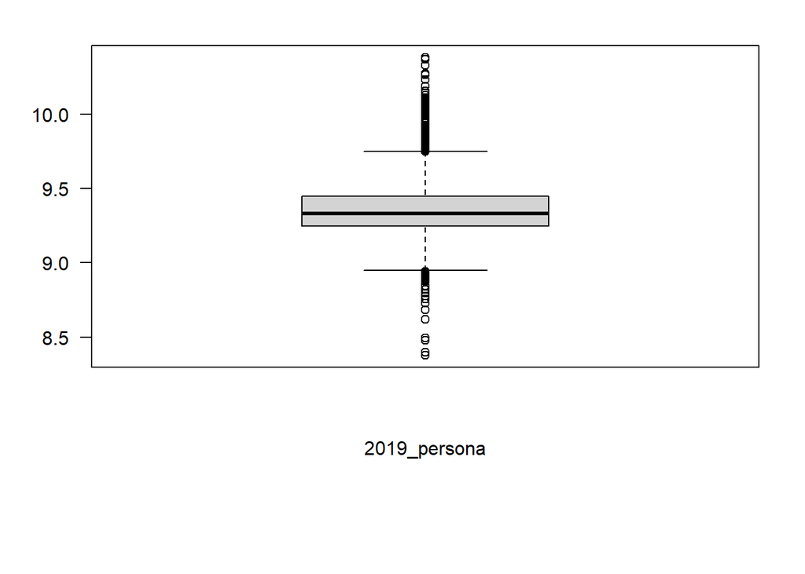

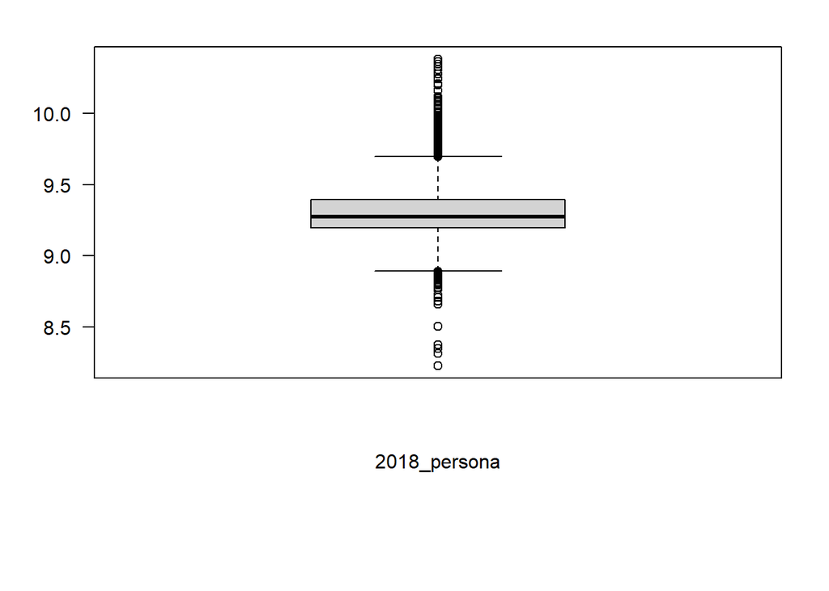

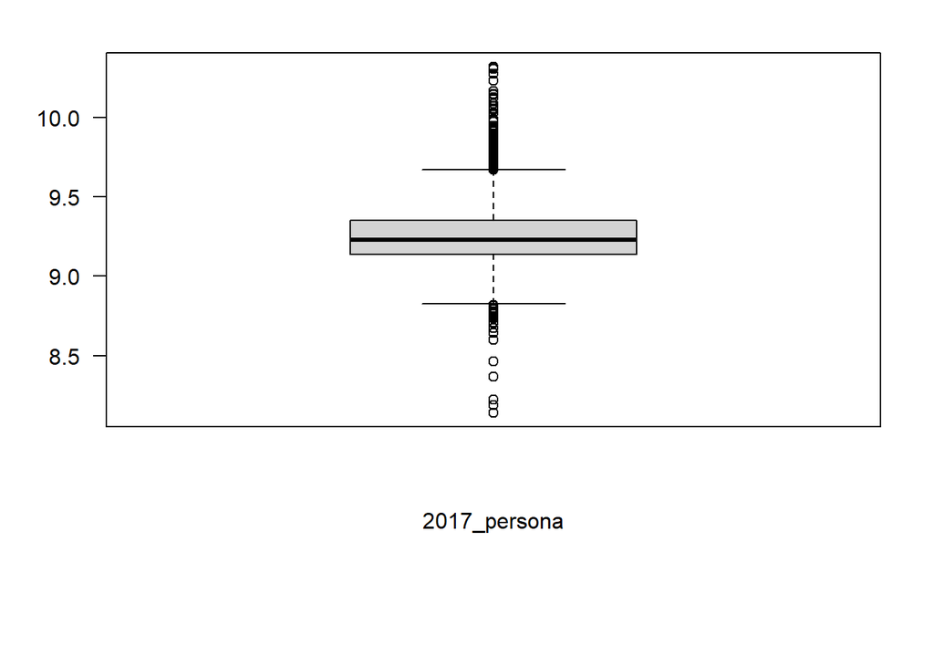

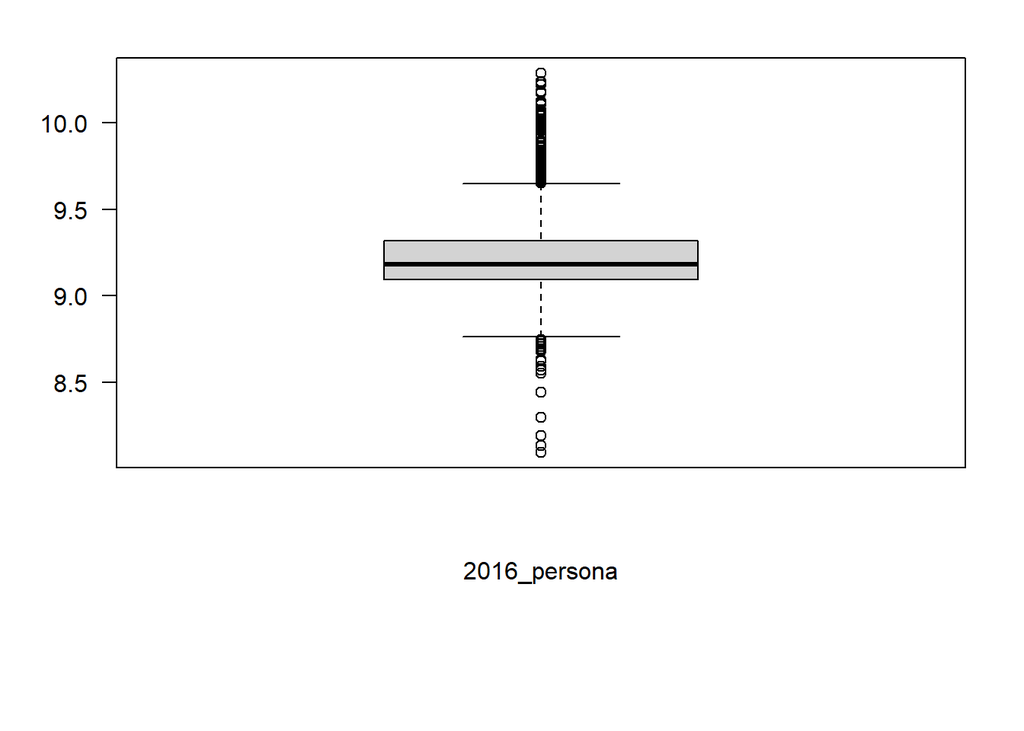

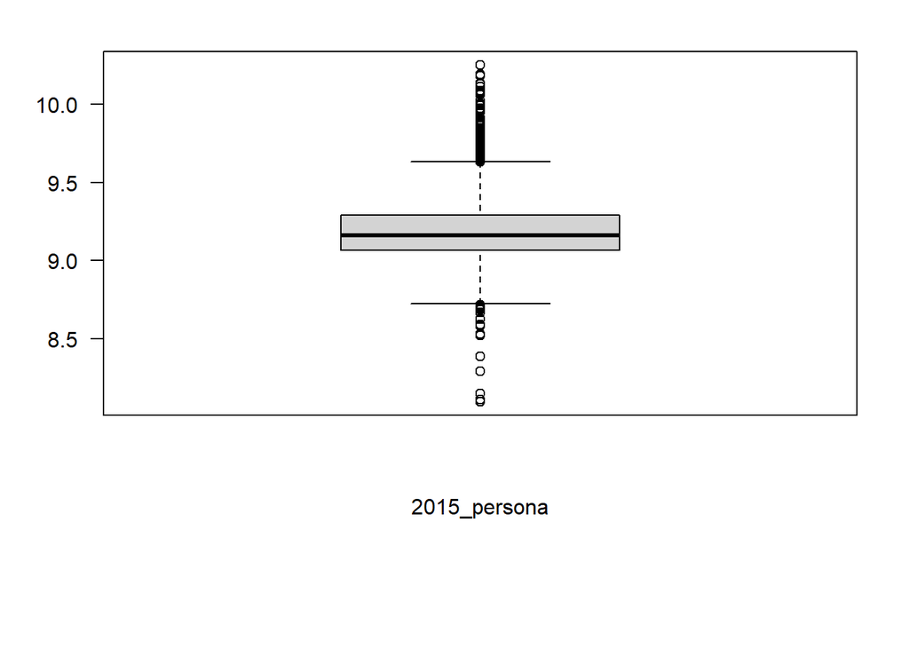

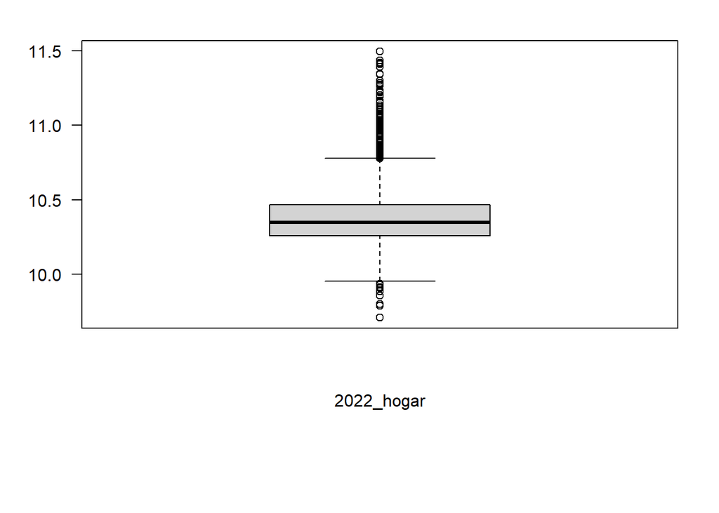

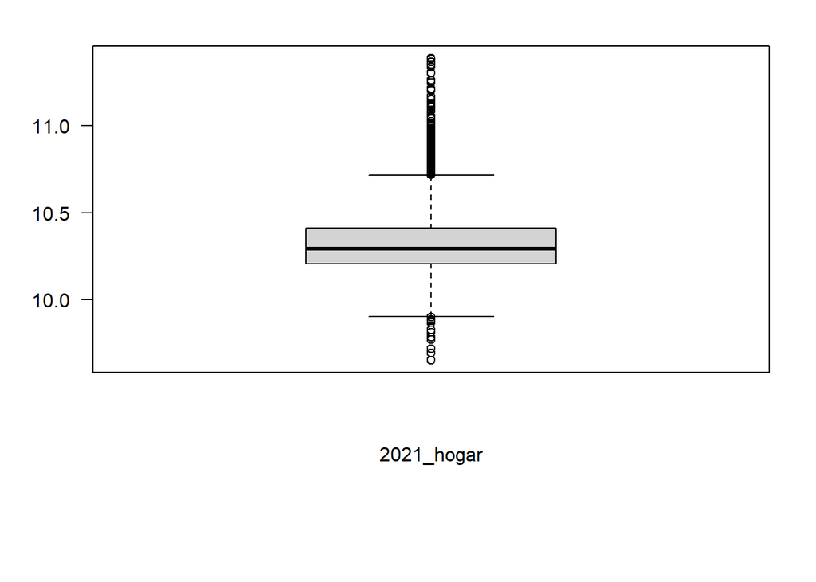

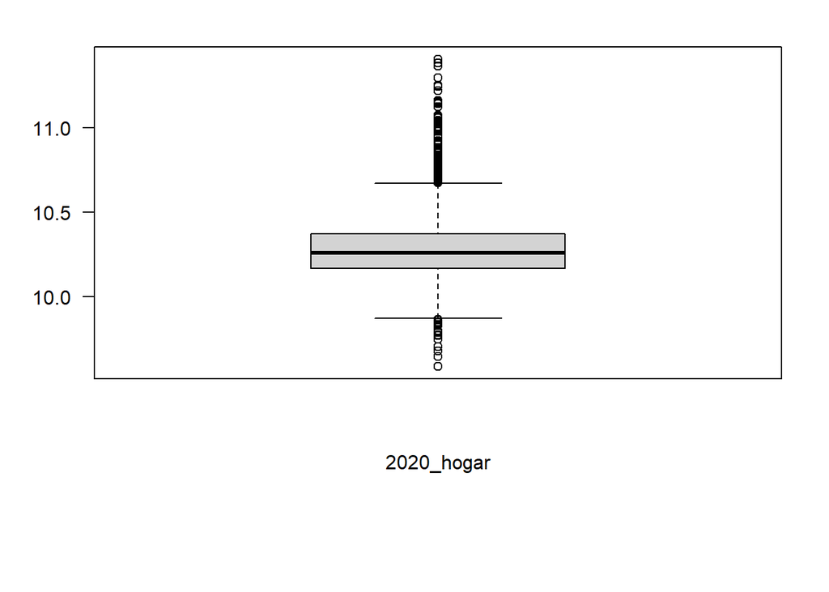

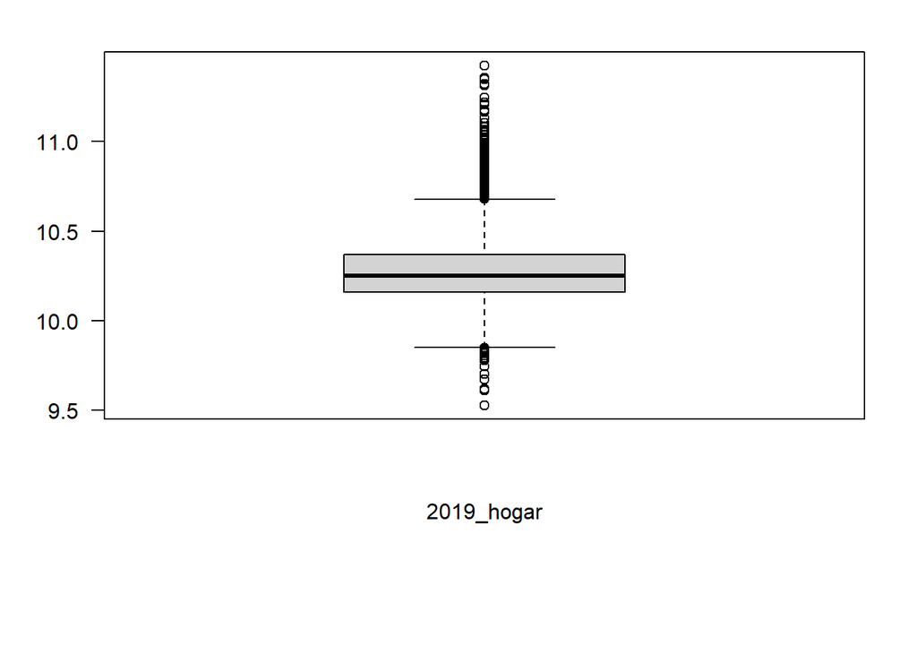

[28 more figures not shown]

```r
for (fila in descdat$variable[descdat$tipo=="numerical"]) {
par(mar = c(9,4,2,2))

boxplot(log1p(INE_limpio[,fila]),xlab=fila,las = 2)   # mfcol
}
```

```r
INE_limpio[, 2:ncol(INE_limpio)] <- log(INE_limpio[, 2:ncol(INE_limpio)])
```

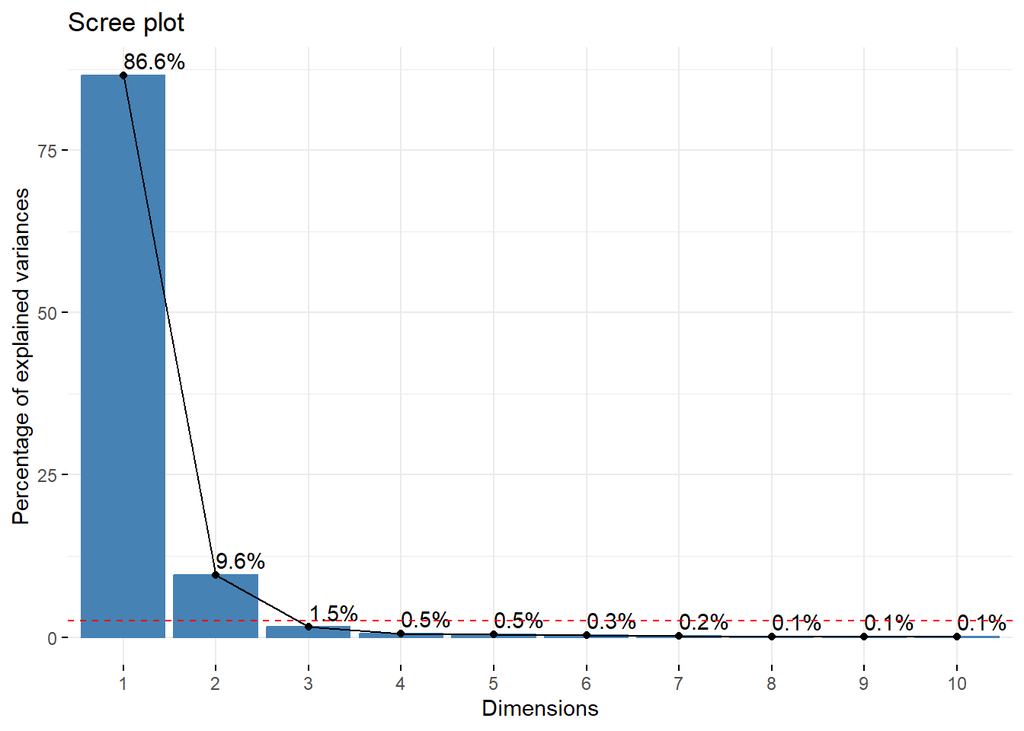

```r
res.pca = PCA(INE_limpio, scale.unit = TRUE, graph = FALSE, ncp = 4,
              quali.sup = c(1))
eig.val <- get_eigenvalue(res.pca)
VPmedio = 100 * (1/nrow(eig.val))
fviz_eig(res.pca, addlabels = TRUE) +
  geom_hline(yintercept=VPmedio, linetype=2, color="red")
```

```r
kable(eig.val[1:16,])
```

|  | eigenvalue | variance.percent | cumulative.variance.percent |
| --- | --- | --- | --- |
| Dim.1 | 34.6362520 | 86.5906300 | 86.59063 |
| Dim.2 | 3.8274157 | 9.5685392 | 96.15917 |
| Dim.3 | 0.6161934 | 1.5404835 | 97.69965 |
| Dim.4 | 0.2102621 | 0.5256552 | 98.22531 |
| Dim.5 | 0.1882349 | 0.4705872 | 98.69590 |
| Dim.6 | 0.1172214 | 0.2930535 | 98.98895 |
| Dim.7 | 0.0684821 | 0.1712053 | 99.16015 |
| Dim.8 | 0.0445314 | 0.1113284 | 99.27148 |
| Dim.9 | 0.0391192 | 0.0977979 | 99.36928 |
| Dim.10 | 0.0354810 | 0.0887026 | 99.45798 |
| Dim.11 | 0.0340854 | 0.0852135 | 99.54320 |
| Dim.12 | 0.0275251 | 0.0688127 | 99.61201 |
| Dim.13 | 0.0229337 | 0.0573342 | 99.66934 |
| Dim.14 | 0.0184035 | 0.0460087 | 99.71535 |
| Dim.15 | 0.0146605 | 0.0366511 | 99.75200 |
| Dim.16 | 0.0142278 | 0.0355694 | 99.78757 |

```r
K = 4
```

```r
res.pca$var$contrib
```

```
##                       Dim.1       Dim.2        Dim.3      Dim.4
## 2022_persona       2.725119  0.18698554 2.423247e+00 5.42124818
## 2021_persona       2.729778  0.16034124 3.016828e+00 3.26336550
## 2020_persona       2.757908  0.13711988 2.567775e+00 0.86909372
## 2019_persona       2.724099  0.12304003 3.204678e+00 0.03228464
## 2018_persona       2.683423  0.09853145 3.647926e+00 1.87991836
## 2017_persona       2.745336  0.11761731 3.635257e+00 2.58428986
## 2016_persona       2.734325  0.11934487 3.438196e+00 5.53720628
## 2015_persona       2.721168  0.14835735 4.239857e+00 5.46122866
## 2022_hogar         2.606316  0.26092580 1.058785e+01 3.04445712
## 2021_hogar         2.624702  0.23693251 1.055162e+01 1.96367948
## 2020_hogar         2.636352  0.22607505 1.054232e+01 0.38911283
## 2019_hogar         2.637033  0.23195842 9.197459e+00 0.02501127
## 2018_hogar         2.630342  0.20296396 7.313358e+00 2.13391264
## 2017_hogar         2.669093  0.23162943 7.822835e+00 2.54669214
## 2016_hogar         2.674403  0.20742716 6.715699e+00 5.16061217
## 2015_hogar         2.689756  0.22938330 5.496341e+00 5.28891796
## 2022_consumo       2.790512  0.18975524 3.934612e-04 5.24863516
## 2021_consumo       2.815433  0.19127917 1.243619e-02 3.06451004
## 2020_consumo       2.818904  0.17563925 9.200501e-04 1.12081980
## 2019_consumo       2.830197  0.15951706 6.038197e-02 0.06535624
## 2018_consumo       2.776692  0.13298828 1.762662e-01 0.95881239
## 2017_consumo       2.831228  0.15486419 1.457808e-01 1.39506061
## 2016_consumo       2.819988  0.14264266 1.635837e-01 3.61746507
## 2015_consumo       2.806068  0.17228861 3.651743e-01 4.11528299
## 2022_bruta_persona 2.567878  1.76192934 1.968152e-01 9.48047985
## 2021_bruta_persona 2.579394  1.88332504 3.031290e-01 6.63264241
## 2020_bruta_persona 2.586811  1.86386121 2.361235e-01 3.47377163
## 2019_bruta_persona 2.588629  1.88130636 4.596611e-01 1.28322763
## 2018_bruta_persona 2.589863  1.75781330 8.536897e-01 0.08987619
## 2017_bruta_persona 2.592560  1.73950231 6.085157e-01 0.28465695
## 2016_bruta_persona 2.588694  1.58232151 6.463491e-01 1.19263015
## 2015_bruta_persona 2.573887  1.69709983 1.109763e+00 1.73546795
## 2022_bruta_hogar   1.696988 10.42124492 1.844440e-02 3.93868704
## 2021_bruta_hogar   1.694455 10.55786982 1.048032e-05 2.24645176
## 2020_bruta_hogar   1.707494 10.46890565 1.745004e-03 1.11149950
## 2019_bruta_hogar   1.725184 10.37525932 7.988391e-03 0.23385118
## 2018_bruta_hogar   1.744214  9.96275482 3.839639e-02 0.19461835
## 2017_bruta_hogar   1.750844 10.09321156 3.735035e-02 0.30542114
## 2016_bruta_hogar   1.765553  9.88917566 3.044357e-02 1.25340212
## 2015_bruta_hogar   1.769376  9.82681160 1.253901e-01 1.35634300
```

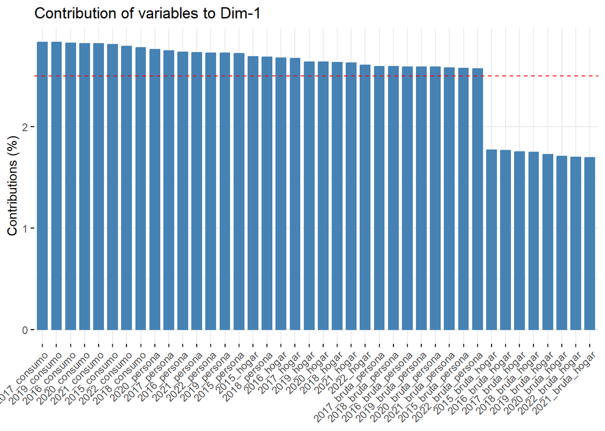

```r
fviz_contrib(res.pca, choice = "var", axes = 1) # PC1
```

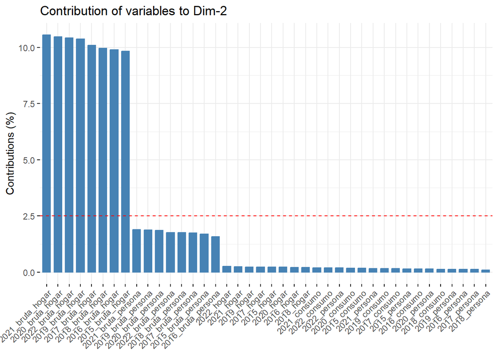

```r
fviz_contrib(res.pca, choice = "var", axes = 2) # PC2
```

###T hotelling

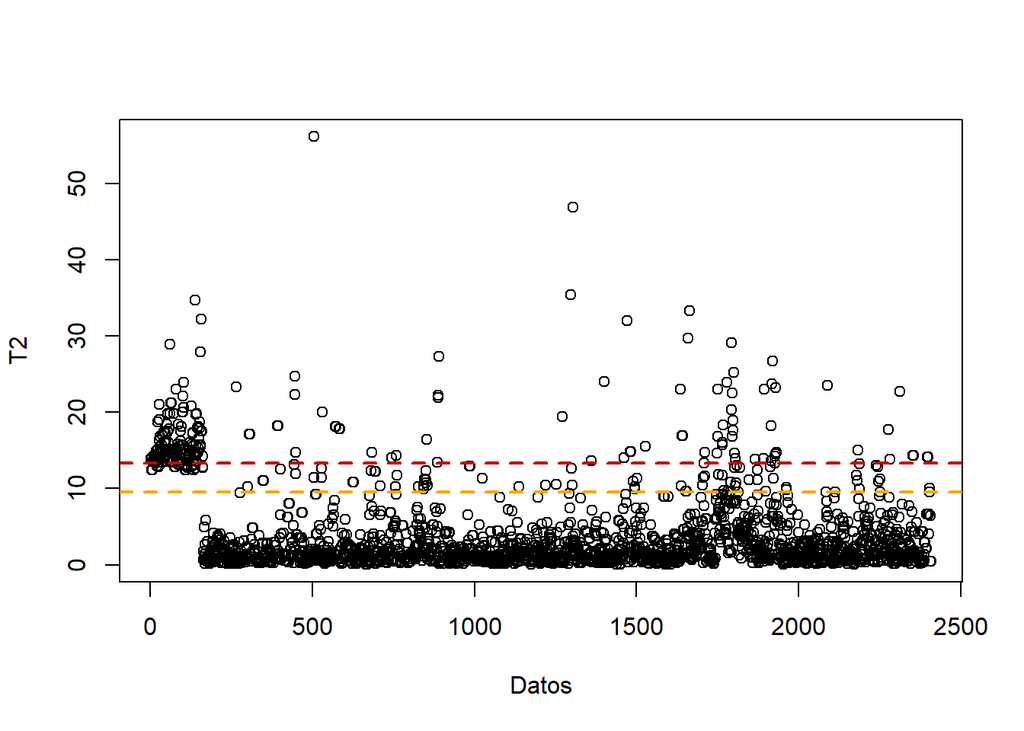

```r
misScores = res.pca$ind$coord[,1:K]
miT2 = colSums(t(misScores**2)/eig.val[1:K,1])
I = nrow(INE_limpio)
F95 = K*(I**2 - 1)/(I*(I - K)) * qf(0.95, K, I-K)
F99 = K*(I**2 - 1)/(I*(I - K)) * qf(0.99, K, I-K)

plot(1:length(miT2), miT2, type = "p", xlab = "Datos", ylab = "T2")
abline(h = F95, col = "orange", lty = 2, lwd = 2)
abline(h = F99, col = "red3", lty = 2, lwd = 2)
```

# Preproceso

```r
ineValencia = read.csv("valenciaINE.csv") # selección de la ciudad de Valencia de todo el fichero
head(INE_limpio)
```

```
## # A tibble: 6 × 41
##   Zona               `2022_persona` `2021_persona` `2020_persona` `2019_persona`
##   <chr>                       <dbl>          <dbl>          <dbl>          <dbl>
## 1 46001 Ademuz                 9.36           9.32           9.26           9.23
## 2 4600101 Ademuz di…           9.36           9.32           9.26           9.23
## 3 4600101001 Ademuz…           9.36           9.32           9.26           9.23
## 4 46002 Ador                   9.41           9.36           9.31           9.27
## 5 4600201 Ador dist…           9.41           9.36           9.31           9.27
## 6 4600201001 Ador s…           9.41           9.36           9.31           9.27
## # ℹ 36 more variables: `2018_persona` <dbl>, `2017_persona` <dbl>,
## #   `2016_persona` <dbl>, `2015_persona` <dbl>, `2022_hogar` <dbl>,
## #   `2021_hogar` <dbl>, `2020_hogar` <dbl>, `2019_hogar` <dbl>,
## #   `2018_hogar` <dbl>, `2017_hogar` <dbl>, `2016_hogar` <dbl>,
## #   `2015_hogar` <dbl>, `2022_consumo` <dbl>, `2021_consumo` <dbl>,
## #   `2020_consumo` <dbl>, `2019_consumo` <dbl>, `2018_consumo` <dbl>,
## #   `2017_consumo` <dbl>, `2016_consumo` <dbl>, `2015_consumo` <dbl>, …
```

```r
INE_limpio$zona_general <- sub(
  pattern = "^([0-9]{5}).*?\\s+(.*?)(\\s+distrito.*|\\s+sección.*|$)",
  replacement = "\\1 \\2",
  x = INE_limpio$Zona
)
#print(unique(val$neighbourhood_cleansed))
#print(unique(val$neighbourhood_group_cleansed))
#print(unique(ine$Zona))
print(unique(INE_limpio$zona_general))
```

```
##   [1] "46001 Ademuz"                  "46002 Ador"
##   [3] "46003 d'Albaida"               "46004 Agullent"
##   [5] "46005 Alaquàs"                 "46006 Albaida"
##   [7] "46007 Albal"                   "46008 Ribera"
##   [9] "46009 Sorells"                 "46010 Tarongers"
##  [11] "46011 Alberic"                 "46012 Alborache"
##  [13] "46013 Alboraia/Alboraya"       "46014 Albuixech"
##  [15] "46015 Alcàsser"                "46016 Xúquer"
##  [17] "46017 Alzira"                  "46018 Alcublas"
##  [19] "46019 l'"                      "46020 l'"
##  [21] "46021 Aldaia"                  "46022 Alfafar"
##  [23] "46023 Alfauir"                 "46024 Baronia"
##  [25] "46025 Patriarca"               "46026 Alfarb"
##  [27] "46026 Alfarp"                  "46027 Alfarrasí"
##  [29] "46028 Palància"                "46028 Palancia"
```

[output cut: 118 more lines]

Tras la lectura de los datos eliminamos de la tabla del INE las filas que contengan la palabra Distrito o Sección, creando una nueva variable llamada zona_general en la que almacenamos las ciudades de las que tenemos datos. La que nos interesa es València, la salida `333` del código anterior.

```r
# Pretendemos generar un archivo csv en el que podamos añadir cómodamente a mano
# el código y nombre del barrio de cada sección de Valencia para realizar más adelante
# el análisis del precio de la vivienda en relación con la renta media por barrio.
# la fuente de datos de barrios y secciones:
# 'https://www.valencia.es/cas/distritos'
library(dplyr)
library(readr)


# Filtrar solo las filas que contienen la palabra "sección"
datos_secciones <- ineValencia %>%
  filter(grepl("sección", ineValencia[[1]]))   # Asume que la columna 1 es la de códigos

# Renombrar la primera columna para mayor claridad
names(datos_secciones)[1] <- "Codigo"

# Separar los componentes del código
datos_procesados <- datos_secciones %>%
  mutate(
    Codigo_Ciudad = substr(Codigo, 1, 5),
    Codigo_Distrito = substr(Codigo, 6, 7),
    Codigo_Seccion = substr(Codigo, 8, 11),
    Codigo_Barrio = "",  # Para rellenarlo a mano con los datos del ayuntamiento de Valencia
    Nombre_Ciudad = "València",
    Nombre_Distrito = paste("Distrito", Codigo_Distrito),
    Nombre_Barrio = ""   # Para rellenarlo según el código del barrio
  ) %>%
  select(
    Codigo_Ciudad,
    Codigo_Distrito,
    Codigo_Barrio,
    Codigo_Seccion,
    Nombre_Ciudad,
    Nombre_Distrito,
    Nombre_Barrio,
    everything()  # El resto de columnas de datos
  )

# Guardar el resultado en un nuevo archivo CSV
write_csv(datos_procesados, "ineValencia_desglosado.csv")
```

Se añade manualmente a continuación en el fichero obtenido los códigos y nombres de barrios a cada fila para tener finalmente el archivo completo con todos los datos que podemos necesitar para relacionar esta base de datos con el resto.

```r
ine = read.csv("ineValenciaFinal.csv", sep = ";")

head(ine)
```

```
##   Codigo_Ciudad Codigo_Distrito Codigo_Barrio Codigo_Seccion Nombre_Ciudad
## 1         46250               1             1              1      València
## 2         46250               1             1              2      València
## 3         46250               1             1              3      València
## 4         46250               1             2              5      València
## 5         46250               1             2              7      València
## 6         46250               1             2              8      València
##   Nombre_Distrito Nombre_Barrio                            Codigo X2022_persona
## 1     Distrito 01        La Seu 4625001001 València sección 01001         20681
## 2     Distrito 01        La Seu 4625001002 València sección 01002         20714
## 3     Distrito 01        La Seu 4625001003 València sección 01003         21274
## 4     Distrito 01      La Xerea 4625001005 València sección 01005         21439
## 5     Distrito 01      La Xerea 4625001007 València sección 01007         27333
## 6     Distrito 01      La Xerea 4625001008 València sección 01008         25027
##   X2021_persona X2020_persona X2019_persona X2018_persona X2017_persona
```

[output cut: 62 more lines]

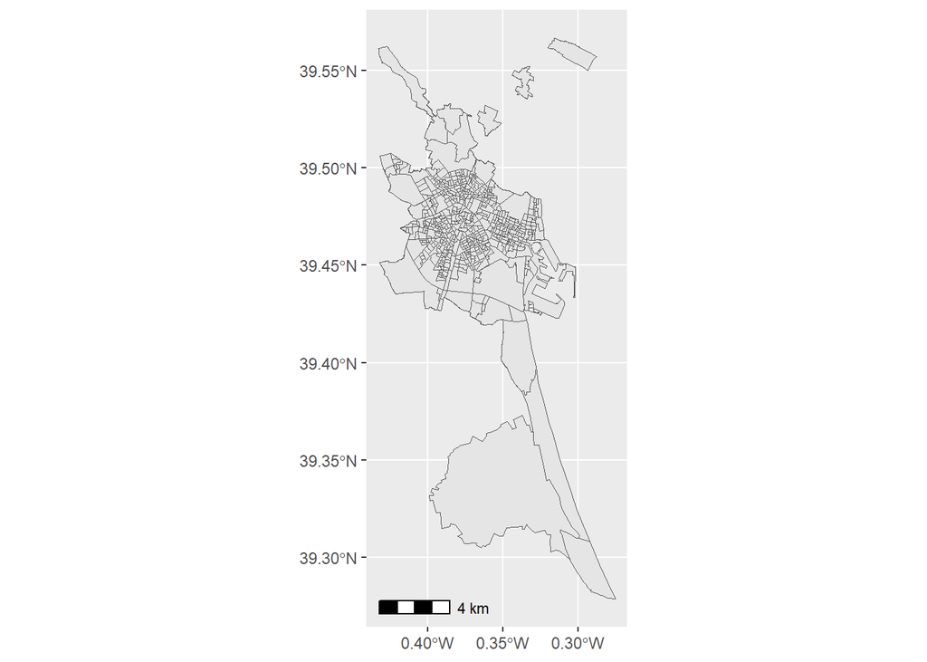

Por último en este fichero se comprueba la posibilidad de graficar el mapa de Valencia a partir de las secciones incluidas en el archivo de Valencia.geojson.